# Chapter 9

## Correlation (Part 2)

### AJ Smit

### 2020/06/28 (updated: 2020-07-03)

# Doing the correlation

## What function do we use to do the correlation?

The name of a very basic function for a correlation test is `cor()`.

Let's find some help on the function first:

```r
?cor # or,
help(cor)
```

## How do we do the Pearson Product Moment correlation?

The equation for the Pearson's correlation coefficient is:

`$$r = \frac{\sum_{i=1}^{n}(x_{i}-\bar{x})(y_{i}-\bar{y})}{\sqrt{\sum_{i=1}^{n}(x_{i}-\bar{x})^2\sum_{i=1}^{n}(y_{i}-\bar{y})}}$$`

Where `\(\bar{x}\)` and `\(\bar{y}\)` are the means for the X and Y variables, respectively.

The default for `cor()` is to fit a Pearson correlation, so we may omit the `method` argument:

```r
with(setosa, cor(Sepal.Length, Sepal.Width))
```

```
R> [1] 0.7425467
```

## What does the output mean?

The output and interpretation are simple. There are not associated *p*-values. There are no associated hypothesis tests. It simply tells of about the strength of association between the two variables.

## A more comprehensive correlation

We can do a more detailed correlation using `cor.test()`:

```r
with(setosa, cor.test(x = Sepal.Length, Sepal.Width))
```

```
R>
R> 	Pearson's product-moment correlation
R>
R> data:  Sepal.Length and Sepal.Width
R> t = 7.6807, df = 48, p-value = 6.71e-10
R> alternative hypothesis: true correlation is not equal to 0
R> 95 percent confidence interval:
R>  0.5851391 0.8460314
R> sample estimates:
R>       cor
R> 0.7425467
```

## What if want to see the association between all the variables in the `setosa` dataset?

For this we can rely on the `cor()` function again:

```r
setosa_pearson <- cor(setosa)
setosa_pearson
```

```
R>              Sepal.Length Sepal.Width Petal.Length Petal.Width
R> Sepal.Length    1.0000000   0.7425467    0.2671758   0.2780984
R> Sepal.Width     0.7425467   1.0000000    0.1777000   0.2327520
R> Petal.Length    0.2671758   0.1777000    1.0000000   0.3316300
R> Petal.Width     0.2780984   0.2327520    0.3316300   1.0000000
```

## How would we visualise all these associations?

In the Iris dataset, above, we compared associations for each pair of the following columns: `Sepal.Length`, `Sepal.Width`, `Petal.Length`, and `Petal.Width`. This required six pairs of correlations, which would be a pain if we wanted to create a visualisation for each of the six pairs. We can do it quickly, e.g.:

```r
ecklonia <- read_csv("../data/ecklonia.csv") %>%
  select(-species, - site, - ID)
head(ecklonia)
```

```
R> # A tibble: 6 x 9
R>   stipe_length stipe_diameter frond_length digits primary_blade_w…
R>          <dbl>          <dbl>        <dbl>  <dbl>            <dbl>
R> 1          456           23.5          116      6             15
R> 2          477           27            141      6             20
R> 3          427           17.5          144      7             10
R> 4          347           22.5          127      5             12
R> 5          470           17            160      5             11
R> 6          478           17.5          181      4             10.5
R> # … with 4 more variables: primary_blade_length <dbl>, stipe_mass <dbl>,
R> #   frond_mass <dbl>, epiphyte_length <dbl>
```

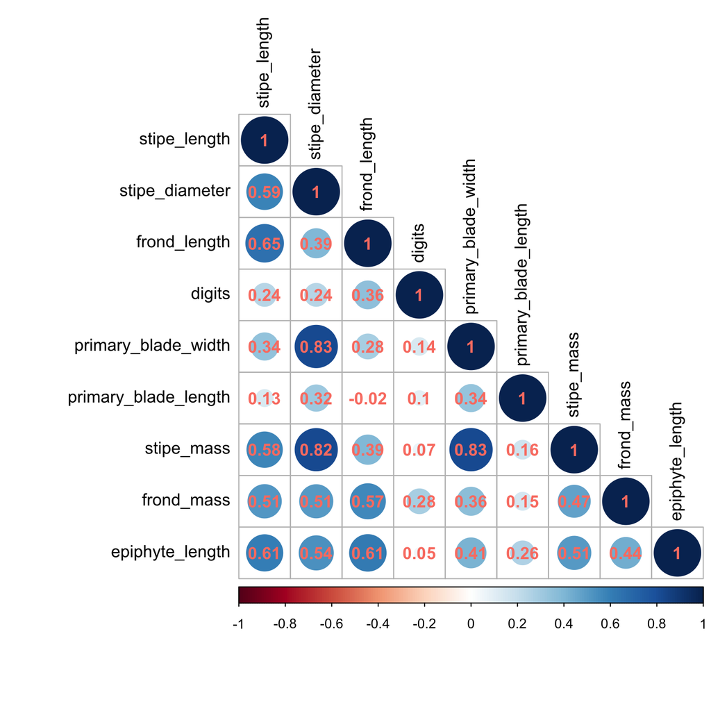

```r
ecklonia_pearson <- cor(ecklonia)
library(corrplot)
corrplot(ecklonia_pearson, method = "circle", type = "lower",
         number.digits = 2, addCoef.col = "salmon", tl.col = "black")
```

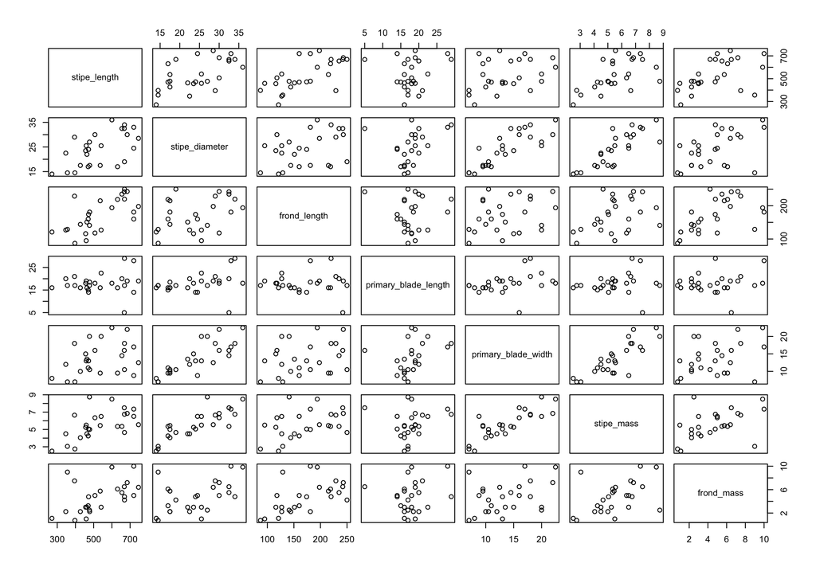

```r
pairs(data = ecklonia, ~ stipe_length + stipe_diameter + frond_length + primary_blade_length +
        primary_blade_width + stipe_mass + frond_mass)
```

## What if we had ordinal data instead of continuous data?

Ordinal data are ordered categorical factors; in other words, the data are rank ordered. Let us create a test dataset:

```r
lungs <- read_tsv("../data/LungCapData.csv") %>%
  mutate(size_class_intervals = as.factor(cut(Height, breaks = 4)),
         size_class = cut(Height, breaks = 4, labels = c("infant", "toddler", "adolecent", "teen"),
                          ordered = TRUE))
head(lungs)
```

```
R> # A tibble: 6 x 8
R>   LungCap   Age Height Smoke Gender Caesarean size_class_intervals size_class
R>     <dbl> <dbl>  <dbl> <chr> <chr>  <chr>     <fct>                <ord>
R> 1    6.48     6   62.1 no    male   no        (54.4,63.5]          toddler
R> 2   10.1     18   74.7 yes   female no        (72.7,81.8]          teen
R> 3    9.55    16   69.7 no    female yes       (63.5,72.7]          adolecent
R> 4   11.1     14   71   no    male   no        (63.5,72.7]          adolecent
R> 5    4.8      5   56.9 no    male   no        (54.4,63.5]          toddler
R> 6    6.22    11   58.7 no    female no        (54.4,63.5]          toddler
```

For more information about creating categorical data from continuous data, see <https://www.youtube.com/watch?v=EWs1Ordh8nI>.

```r
is.ordered(lungs$size_class)
```

```
R> [1] TRUE
```

```r
head(as.numeric(lungs$size_class), 111)
```

```
R>   [1] 2 4 3 3 2 2 2 3 3 2 4 3 2 2 2 2 2 2 2 3 2 2 3 3 3 2 2 3 1 3 1 3 3 3 3 3 1
R>  [38] 3 3 4 3 3 2 3 1 2 2 3 4 2 3 4 3 2 4 1 3 4 2 3 2 3 2 2 3 3 2 2 3 3 2 3 1 3
R>  [75] 2 2 3 2 3 3 2 3 3 4 2 2 4 2 2 4 3 3 4 3 4 4 3 3 4 2 3 3 2 4 3 1 4 3 2 1 3
```

The equation for Spearman's *rho* is:

`$$r = \frac{\sum_{i=1}^{n}(x_{i}'-\bar{x})(y_{i}'-\bar{y})}{\sqrt{\sum_{i=1}^{n}(x_{i}'-\bar{x})^2\sum_{i=1}^{n}(y_{i}'-\bar{y})}}$$`

Where `\(x_{i}'\)` and `\(y_{i}'\)` are the ranks for each observation in the X and Y variables, respectively.

## How do we apply a Spearman's *rho* correlation by ranks?

```r
cor.test(as.numeric(lungs$size_class), lungs$LungCap, method = "spearman")
```

```
R>
R> 	Spearman's rank correlation rho
R>
R> data:  as.numeric(lungs$size_class) and lungs$LungCap
R> S = 9358124, p-value < 2.2e-16
R> alternative hypothesis: true rho is not equal to 0
R> sample estimates:
R>       rho
R> 0.8526579
```

## Questions

Find your own data set suitable for a correlation analysis.

- State the null and alternative hypotheses. Do a Pearson's correlation. Explain the findings.
- Do the tests necessary to evaluate the various assumptions for the above analysis.
- Create all the associated figures for the above analysis.
- Transform one of the variables to ordinal data, and do a Spearman's *rho* or Kendall's *tau* correlation. Explain the findings.

- Do a full correlation analysis on the full `iris` dataset (i.e. all three species):

- state all null hypotheses;

- test all assumptions;

- create all necessary plots;

- write a few sentences on the findings.